# `platexpress`: microbial growth & gene expression

Rainer Machne

2016-12-06

The `platexpress` package provides a quick & easy interface to microbial growth & gene expression data as measured in parallel growth platforms such as microplate readers. It allows for quick inspection of raw data, blank normalization, and summarization over replicates.

A few data conversion routines allow to interface to R packages [grofit](https://cran.r-project.org/web/packages/grofit/index.html) and [cellGrowth](https://www.bioconductor.org/packages/release/bioc/html/cellGrowth.html) to fit a variety of microbial growth models.

## Installation

`platexpress` is currently under heavy development and there is no official release yet. You can download from github and run:

```
R CMD build platexpress/
R CMD INSTALL platexpress_0.1.tar.gz
```

or use the library `devtools`:

```r
install.packages("devtools") # if not installed already
library(devtools)
install_github("raim/platexpress")
```

## A Typical Workflow in `platexpress`

NOTE: the following examples are all executed step-by-step in an R `demo()` that comes with the library. For a quick tour of the following, open R and type:

```r
library(platexpress)
demo("demo_ap12",package="platexpress")
```

### 1) Parse the plate layout and measurements

The plate layout will later allow to do blank correction and group experiments. Here, we take the example file that ships with the `platexpress` library:

```r
library(platexpress)
plate.file <- system.file("extdata", "AP12_layout.csv", package = "platexpress")
plate <- readPlateMap(file=plate.file, blank.id="blank",fsep="\n", fields=c("strain","samples"))
```

… and parse the data, as exported from platereader “Synergy Mx” software in the shipped example file:

```r
data.file <- system.file("extdata", "AP12.csv", package = "platexpress")
raw <- readPlateData(file=data.file, type="Synergy", data.ids=c("600","YFP_50:500,535"), time.format="%H:%M:%S", time.conversion=1/3600)
```

```
## Interpolating all data to a single master time.
```

Here we include some specifics for this data set. First, we need to specify from which plate-reader the file was exported. `platexpress` can currently read files exported from “Synergy Mx” and “BMG Optima” software. Please let us know, if you need other formats to be implemented. Even, if we now the plate-reader some things always change between exported data sets. E.g., the example file was exported with times in format HH:MM:SS, and we need to tell it to our parser via the argument `time.format` (see R base function `base::strptime`). The resulting time is in seconds but we would prefer hours, i.e., divide it by 3600. This is done by the `time.conversion` argument, although in this case you could simply convert it manually with `raw$Time <- raw$Time/3600` as well.

Generally, parsing a new data file, freshly exported from the plate-reader or from a spread-sheet program is likely to cause problems. You should take care at this step. Problems with data parsing are usually the most time-consuming step in data analysis!

### 2) Inspect and process the raw data

Take a first look:

```
## x-axis: Time
## plotting 600;YFP_50:500,535
```

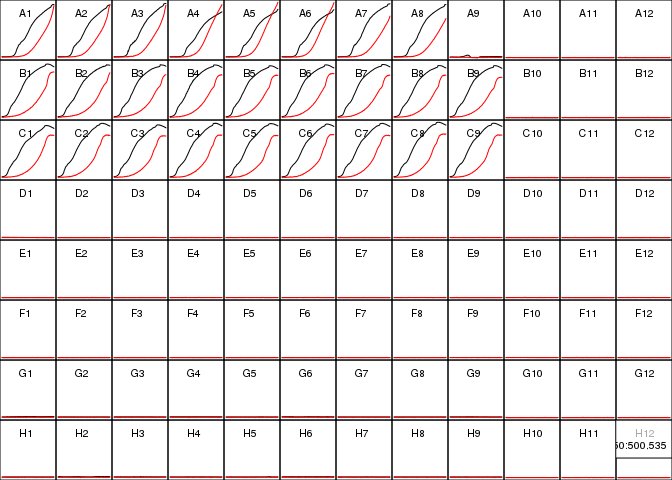

… and note that there is no growth in well A9, so let’s skip it. To be safe, let’s also skip it from the plate layout map.

```r
raw <- skipWells(raw, skip="A9")
plate <- skipWells(plate, skip="A9")
```

… correct for blank well measurements (defined in the plate layout map!), assign colors and nicer IDs, and view only the present rows (A, B and C) and columns (1-9):

```r
data <- correctBlanks(data=raw, plate=plate)
```

```
## blanking 600;YFP_50:500,535
## blanking TRUE : 77 wells, using 18 blank wells
## 600
##  time bin: 1 1 - 241 blank: 0.0558678339436354
## YFP_50:500,535
##  time bin: 1 1 - 241 blank: 26.4687518257613
```

```r
viewPlate(data, rows=c("A","B","C"),cols=1:9)
```

```
## x-axis: Time
## plotting 600;YFP_50:500,535
```

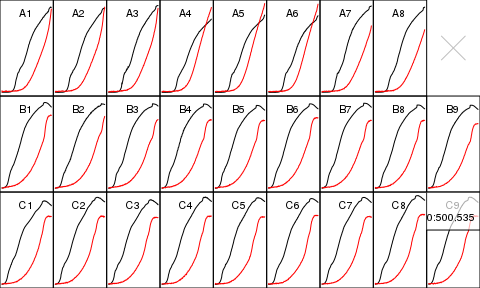

Now the raw data processing is done, so let’s assign more informative IDs and select nicer colors, as R RGB strings:

```r
data <- prettyData(data=raw,dids=c(OD="600",YFP="YFP_50:500,535"),
                   colors=c(OD="#000000",YFP=wavelength2RGB(690)))
```

Note that helper functions `showSpectrum()` and `findWavelength(1)` allow to select colors from a spectrum of visible light and gives you the required RGB strings. Or you can convert a wavlength in nm directly to RGB using `wavelength2RGB(500)` for the estimated RGB value of 500 nm light.

### 3) Group replicates

Next, generate groups over replicates and strains and view summarized growth vs. expression curves for these groups. The areas indicate the t-test based 95% confidence interval, the thick line is the mean, and optionally, you can keep also the original data in the plot (by choosing a lwd.orig > 0):

```r
groups <- getGroups(plate, by="strain")
```

```
##  group EVC : 8 wells, skipping 0 blank wells
##  group D50 : 9 wells, skipping 0 blank wells
##  group D50.1 : 9 wells, skipping 0 blank wells
```

```r
viewGroups(data,groups=groups,lwd.orig=0.1,nrow=1)
```

```
## x-axis: Time
## y-axis: OD;YFP
```

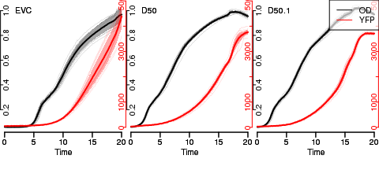

or view all in one

```r
viewGroups(data,groups2=groups,lwd.orig=0.1,nrow=1)
```

```
## x-axis: Time
## y-axis: OD;YFP
```

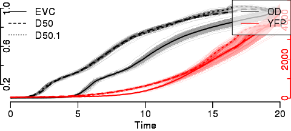

### 4) Advanced analyses

#### Correct For Lag Phase

```r
lag <- rep(3, length(groups$EVC))
names(lag) <- groups$EVC
data <- shiftData(data, lag=lag)
viewGroups(data,groups2=groups,lwd.orig=0,nrow=1)
```

```
## x-axis: Time
## y-axis: OD;YFP
```

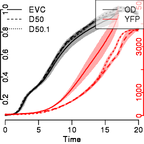

Great! Now the OD curves are aligned, and they seem to be very similar, allowing a direct comparison of fluorescence over time.

#### Generate Box- or Barplots

For some applications you may want to boil data down to core messages. Diverse further functions allow to further summarize and visualize results, e.g., gives you boxplots or barplots (with standard errors or 95% confidence intervals as errors bars) of the selected data at 7 h (or the time-point closest to 7h).

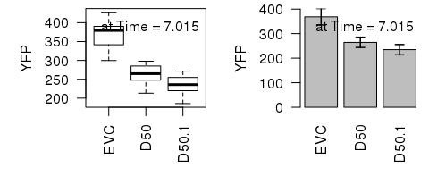

```r
par(mfcol=c(1,2), mai=c(1,1,.1,.1))
boxData(data,rng=7,groups=groups,did="YFP")
boxData(data,rng=7,groups=groups,did="YFP",type="bar")
```

#### Retrieve and Process Data

The OD growth curves were nicely aligned, however, you may still want to normalize your data by OD and look at YFP expression in dependence of OD. You can `getData` and `addData`, e.g., to calculate YFP/OD:

```r
yfp <- getData(data, "YFP")
od <- getData(data, "OD")
data <- addData(data, dat=yfp/od, ID="YFP/OD", col=wavelength2RGB(459))
viewGroups(data,groups2=groups,lwd.orig=0,dids=c("OD","YFP/OD"))
```

```
## x-axis: Time
## y-axis: OD;YFP/OD
```

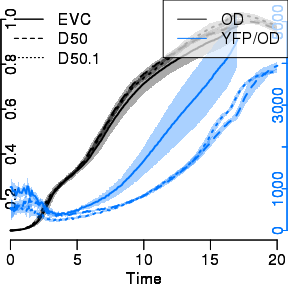

#### Interpolate to new x-axis

You could also plot data against another x-axis, any data set in your data, e.g., by using `xid="OD"` in the call to `viewPlate` or `viewGroup`. However, since the x-axis is distinct for each data point, you won’t get the nice 95% confidence intervals. For this we can interpolate data to a common value. This generates a new data structure, and the two should not be mixed up:

```r
od.data <- interpolatePlateData(data, xid="OD")
viewGroups(od.data,groups2=groups,dids=c("YFP","YFP/OD"))
```

```
## x-axis: OD
## y-axis: YFP;YFP/OD
```

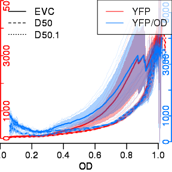

And now we are ready for nice compact result figure:

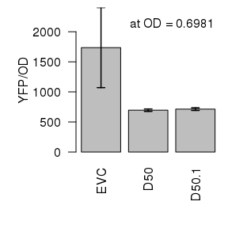

```r
par(mai=c(1,1,.1,.1))
boxData(od.data,rng=0.7,groups=groups,did="YFP/OD",type="bar")
```